# Lab 3

Ani Ruhil

January 25, 2016

# Practice Problem 1

Systolic blood pressure was measured (in units of mm Hg) during preventative health examinations on people in Dallas, Texas. Here are the measurements for some of these patients:

```r
y = c(112, 128, 108, 129, 125, 153, 155, 132, 137)
```

1. Calculate the mean and the standard deviation for these data.

```r
mean.y = mean(y)
sd.y =sd(y)
mean.y; sd.y
```

```
## [1] 131
```

```
## [1] 15.95306
```

2. What is the sample size?

```r
n = length(y)
n
```

```
## [1] 9
```

3. Calculate the standard error of the mean.

```r
se.y = sd.y / sqrt(n)
se.y
```

```
## [1] 5.317685
```

The standard error of the mean is 5.31

4. Using the 2SE rule of thumb, calculate an approximate 95% confidence interval for the mean. List the lower and upper limits.

```r
lower.CI.limit = mean.y - (2 * se.y)
upper.CI.limit = mean.y + (2 * se.y)
lower.CI.limit; upper.CI.limit
```

```
## [1] 120.3646
```

```
## [1] 141.6354
```

The lower and upper limits of the confidence interval are 120.36 mm Hg and 141.63 mm Hg.

5. How would we interpret the 95% confidence interval?

We can be about 95% certain that the population mean of systolic blood pressure lies in the range of values given by 120.36 mm Hg and 141.63 mm Hg.

6. Draw a strip-chart with the mean and the standard errors overlaid on the data.

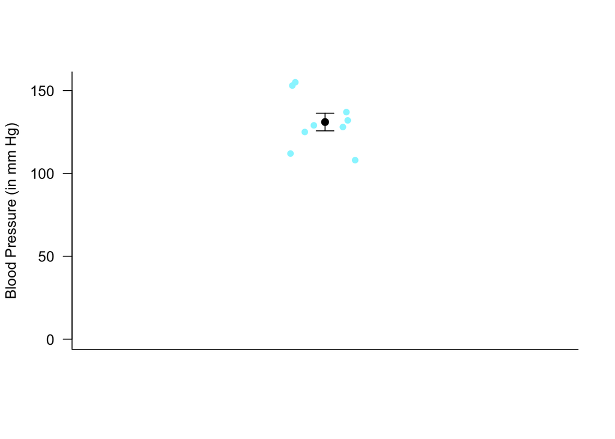

```r
par(bty = "l") # Just draw x-axis and y-axis; no box around the plot

stripchart(y, vertical = TRUE, method = "jitter", jitter = 0.01, pch = 16, ylab = "Blood Pressure (in mm Hg)", col = "cadetblue1", cex = 1, las = 1, ylim = c(0, max(y)))

points(mean.y, pch = 16, cex = 1.2)

arrows( c(1), mean.y - se.y, c(1), mean.y + se.y,   angle = 90, code = 3, length = 0.1)
```

# Practice Problem 7

Niderkorn’s (1872) measurements on 114 human corpses provided the first quantitative study on the development of rigor mortis. These data, given below, reflect the number of hours it took a body to achieve rigor mortis after death. Note the data have been rounded to the nearest hour (hence there are no decimal places).

```r
rmortis = read.csv("http://whitlockschluter.zoology.ubc.ca/wp-content/data/chapter03/chap03q09Rigormortis.csv")
```

1. What is the average time to rigor mortis for these data?

```r
mean.hours = mean(rmortis$hours)
mean.hours
```

```
## [1] 5.684211
```

The average time to rigor mortis is 5.68 hours.

2. What is the standard deviation?

```r
sd.hours = sd(rmortis$hours)
sd.hours
```

```
## [1] 2.362374
```

The standard deviation is 2.36 hours.

3. Calculate and interpret the standard error for the mean of these data.

```r
n.hours = length(rmortis$hours)
n.hours
```

```
## [1] 114
```

```r
se.hours = sd.hours / sqrt(n.hours)
se.hours
```

```
## [1] 0.2212566
```

The standard error is 0.22 hours, and this can be interpreted as the average difference we might expect, between our sample mean and the population, in a random sample of 114 cadavers.

4. What is the approximate 95% confidence interval for the sample mean you estimated earlier? How would we interpret the lower and upper limits of this interval?

```r
lower.CI = mean.hours - (2 * se.hours)
upper.CI = mean.hours + (2 * se.hours)
lower.CI; upper.CI
```

```
## [1] 5.241697
```

```
## [1] 6.126724
```

The approximate 95% interval is 5.24 and 6.12 hours. The interpretation would be that we can be about 95% certain that for the population at large the average time to rigor mortis falls between 5.24 and 6.12 hours.

5. Draw a strip-chart with the mean and the standard errors overlaid on the data.

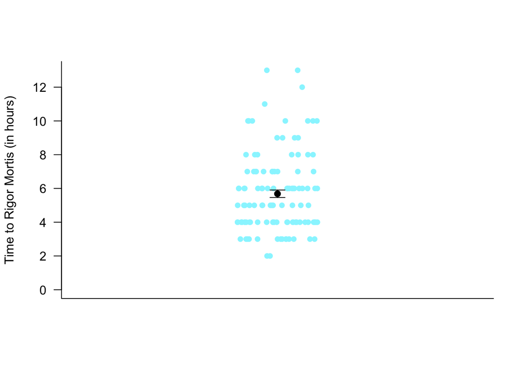

```r
par(bty = "l") # Just draw x-axis and y-axis; no box around the plot

stripchart(rmortis$hours, vertical = TRUE, method = "jitter", jitter = 0.01, pch = 16, ylab = "Time to Rigor Mortis (in hours)", col = "cadetblue1", cex = 1, las = 1, ylim = c(0, max(rmortis$hours)))

points(mean.hours, pch = 16, cex = 1.2)

arrows( c(1), mean.hours - se.hours, c(1), mean.hours + se.hours,   angle = 90, code = 3, length = 0.1)
```

# Your Turn …